# Tutorial 2B - Different classifiers

## Week 2 - Different classifiers

Here, we look at building models using the different classifiers (discussed in the lectures) from scikit-learn.

#### Import packages

```python
import numpy as np
import pandas as pd

#from graphviz import Source # required for printing decision trees in graphic format
from sklearn.naive_bayes import GaussianNB
from sklearn.neighbors import KNeighborsClassifier
from sklearn.tree import DecisionTreeClassifier, export_graphviz

# model utils
from sklearn.metrics import accuracy_score
from sklearn.preprocessing import LabelEncoder
from sklearn.model_selection import train_test_split
from sklearn.compose import make_column_selector as selector
```

```python
#Input files - this can be obtained running 'Tutorial 2A - Introduction to machine-learning with scikit-learn.ipynb'
file_adult_census = 'adult_census_normalized_encoded.csv'
```

#### Load data

```python
df = pd.read_csv(file_adult_census)
df.head()
```

|  | age | education-num | workclass_Federal-gov | workclass_Local-gov | workclass_Never-worked | workclass_Private | workclass_Self-emp-inc | workclass_Self-emp-not-inc | workclass_State-gov | workclass_Without-pay | ... | native-region_Asia_East | native-region_Central_America | native-region_Europe_East | native-region_Europe_West | native-region_North_America | native-region_South_America | capital-gain | capital-loss | hours-per-week | income>50K |
| --- | --- | --- | --- | --- | --- | --- | --- | --- | --- | --- | --- | --- | --- | --- | --- | --- | --- | --- | --- | --- | --- |
| 0 | 0.301370 | 13 | 0.0 | 0.0 | 0.0 | 0.0 | 0.0 | 0.0 | 1.0 | 0.0 | ... | 0.0 | 0.0 | 0.0 | 0.0 | 1.0 | 0.0 | 0.0 | 0.0 | 1.0 | 0 |
| 1 | 0.452055 | 13 | 0.0 | 0.0 | 0.0 | 0.0 | 0.0 | 1.0 | 0.0 | 0.0 | ... | 0.0 | 0.0 | 0.0 | 0.0 | 1.0 | 0.0 | 0.0 | 0.0 | 0.0 | 0 |
| 2 | 0.287671 | 9 | 0.0 | 0.0 | 0.0 | 1.0 | 0.0 | 0.0 | 0.0 | 0.0 | ... | 0.0 | 0.0 | 0.0 | 0.0 | 1.0 | 0.0 | 0.0 | 0.0 | 1.0 | 0 |
| 3 | 0.493151 | 7 | 0.0 | 0.0 | 0.0 | 1.0 | 0.0 | 0.0 | 0.0 | 0.0 | ... | 0.0 | 0.0 | 0.0 | 0.0 | 1.0 | 0.0 | 0.0 | 0.0 | 1.0 | 0 |
| 4 | 0.150685 | 13 | 0.0 | 0.0 | 0.0 | 1.0 | 0.0 | 0.0 | 0.0 | 0.0 | ... | 0.0 | 1.0 | 0.0 | 0.0 | 0.0 | 0.0 | 0.0 | 0.0 | 1.0 | 0 |

5 rows × 56 columns

Here, we use the 55 features to determine the outcome of the target variable, `income>50K`.

```python
df.dtypes
```

```
age                                     float64
education-num                             int64
workclass_Federal-gov                   float64
workclass_Local-gov                     float64
workclass_Never-worked                  float64
workclass_Private                       float64
workclass_Self-emp-inc                  float64
workclass_Self-emp-not-inc              float64
workclass_State-gov                     float64
workclass_Without-pay                   float64
marital-status_Divorced                 float64
marital-status_Married-AF-spouse        float64
marital-status_Married-civ-spouse       float64
marital-status_Married-spouse-absent    float64
marital-status_Never-married            float64
marital-status_Separated                float64
marital-status_Widowed                  float64
occupation_Adm-clerical                 float64
occupation_Armed-Forces                 float64
occupation_Craft-repair                 float64
occupation_Exec-managerial              float64
occupation_Farming-fishing              float64
occupation_Handlers-cleaners            float64
occupation_Machine-op-inspct            float64
occupation_None                         float64
occupation_Other-service                float64
occupation_Priv-house-serv              float64
occupation_Prof-specialty               float64
occupation_Protective-serv              float64
occupation_Sales                        float64
occupation_Tech-support                 float64
occupation_Transport-moving             float64
relationship_Husband                    float64
relationship_Not-in-family              float64
relationship_Other-relative             float64
relationship_Own-child                  float64
relationship_Unmarried                  float64
relationship_Wife                       float64
race_Amer-Indian-Eskimo                 float64
race_Asian-Pac-Islander                 float64
race_Black                              float64
race_Other                              float64
race_White                              float64
sex_Female                              float64
sex_Male                                float64
native-region_Asia_Central              float64
native-region_Asia_East                 float64
native-region_Central_America           float64
native-region_Europe_East               float64
native-region_Europe_West               float64
native-region_North_America             float64
native-region_South_America             float64
capital-gain                            float64
capital-loss                            float64
hours-per-week                          float64
income>50K                                int64
dtype: object
```

```python
# Select columns containing categorical data
categorical_columns = df[['education-num', 'capital-gain','capital-loss','hours-per-week']].columns
# MaxDelq2PublicRecLast12M and MaxDelqEver were chosen as categories because
# the data contains single digit values each representing a different meaning

# Convert data type to category for these columns
for column in categorical_columns:
    df[column] = df[column].astype('category')
```

Converted *education-num*, *capital-gain*, *capital-loss*, *hours-per-week* to categorical type.

```python
df.isnull().sum()
```

```
age                                     0
education-num                           0
workclass_Federal-gov                   0
workclass_Local-gov                     0
workclass_Never-worked                  0
workclass_Private                       0
workclass_Self-emp-inc                  0
workclass_Self-emp-not-inc              0
workclass_State-gov                     0
workclass_Without-pay                   0
marital-status_Divorced                 0
marital-status_Married-AF-spouse        0
marital-status_Married-civ-spouse       0
marital-status_Married-spouse-absent    0
marital-status_Never-married            0
marital-status_Separated                0
marital-status_Widowed                  0
occupation_Adm-clerical                 0
occupation_Armed-Forces                 0
occupation_Craft-repair                 0
occupation_Exec-managerial              0
occupation_Farming-fishing              0
occupation_Handlers-cleaners            0
occupation_Machine-op-inspct            0
occupation_None                         0
occupation_Other-service                0
occupation_Priv-house-serv              0
occupation_Prof-specialty               0
occupation_Protective-serv              0
occupation_Sales                        0
occupation_Tech-support                 0
occupation_Transport-moving             0
relationship_Husband                    0
relationship_Not-in-family              0
relationship_Other-relative             0
relationship_Own-child                  0
relationship_Unmarried                  0
relationship_Wife                       0
race_Amer-Indian-Eskimo                 0
race_Asian-Pac-Islander                 0
race_Black                              0
race_Other                              0
race_White                              0
sex_Female                              0
sex_Male                                0
native-region_Asia_Central              0
native-region_Asia_East                 0
native-region_Central_America           0
native-region_Europe_East               0
native-region_Europe_West               0
native-region_North_America             0
native-region_South_America             0
capital-gain                            0
capital-loss                            0
hours-per-week                          0
income>50K                              0
dtype: int64
```

```python
target = df.pop('income>50K')
target.head()
```

```
0    0
1    0
2    0
3    0
4    0
Name: income>50K, dtype: int64
```

```python
df.head()
```

|  | age | education-num | workclass_Federal-gov | workclass_Local-gov | workclass_Never-worked | workclass_Private | workclass_Self-emp-inc | workclass_Self-emp-not-inc | workclass_State-gov | workclass_Without-pay | ... | native-region_Asia_Central | native-region_Asia_East | native-region_Central_America | native-region_Europe_East | native-region_Europe_West | native-region_North_America | native-region_South_America | capital-gain | capital-loss | hours-per-week |
| --- | --- | --- | --- | --- | --- | --- | --- | --- | --- | --- | --- | --- | --- | --- | --- | --- | --- | --- | --- | --- | --- |
| 0 | 0.301370 | 13 | 0.0 | 0.0 | 0.0 | 0.0 | 0.0 | 0.0 | 1.0 | 0.0 | ... | 0.0 | 0.0 | 0.0 | 0.0 | 0.0 | 1.0 | 0.0 | 0.0 | 0.0 | 1.0 |
| 1 | 0.452055 | 13 | 0.0 | 0.0 | 0.0 | 0.0 | 0.0 | 1.0 | 0.0 | 0.0 | ... | 0.0 | 0.0 | 0.0 | 0.0 | 0.0 | 1.0 | 0.0 | 0.0 | 0.0 | 0.0 |
| 2 | 0.287671 | 9 | 0.0 | 0.0 | 0.0 | 1.0 | 0.0 | 0.0 | 0.0 | 0.0 | ... | 0.0 | 0.0 | 0.0 | 0.0 | 0.0 | 1.0 | 0.0 | 0.0 | 0.0 | 1.0 |
| 3 | 0.493151 | 7 | 0.0 | 0.0 | 0.0 | 1.0 | 0.0 | 0.0 | 0.0 | 0.0 | ... | 0.0 | 0.0 | 0.0 | 0.0 | 0.0 | 1.0 | 0.0 | 0.0 | 0.0 | 1.0 |
| 4 | 0.150685 | 13 | 0.0 | 0.0 | 0.0 | 1.0 | 0.0 | 0.0 | 0.0 | 0.0 | ... | 0.0 | 0.0 | 1.0 | 0.0 | 0.0 | 0.0 | 0.0 | 0.0 | 0.0 | 1.0 |

5 rows × 55 columns

#### Train-test split

```python
X_train, X_test, y_train, y_test = train_test_split(df, target, train_size=0.75, random_state=1)
```

### *k* Nearest Neighbour

The default similarity metric for k-NN is Euclidean distance.  
In some circumstances other metrics (or measures) will be more appropriate - for instance correlation. Refer to [documentation](https://scikit-learn.org/stable/modules/neighbors.html#nearest-neighbors-classification)

```python
knn_clf = KNeighborsClassifier()
# fit the KNN model on the motor_insurance training data
knn_clf.fit(X_train, y_train)
```

```
KNeighborsClassifier()
```

```python
# predict on the training dataset
y_predicted = knn_clf.predict(X_train)
accuracy_score(y_train, y_predicted)
```

```
0.8705911574764034
```

```python
# predict if an individual's credit risk performance isgood or bad on the test data using the trained KNN model
y_predicted = knn_clf.predict(X_test)
accuracy_score(y_test, y_predicted)
```

```
0.8180327868852459
```

### Decision Trees

Decision trees are non-parametric models: they are not controlled by a mathematical decision function and do not have weights or intercept to be optimized.

Decision trees will partition the space by considering a single feature at a time. Refer to [documentation](https://scikit-learn.org/stable/modules/tree.html)

```python
dtc = DecisionTreeClassifier(criterion='entropy', max_depth=3)
# fit the Decision Tree model on the athlete training data
dtc.fit(X_train, y_train)
```

```
DecisionTreeClassifier(criterion='entropy', max_depth=3)
```

```python
# predict on the training dataset
y_predicted = dtc.predict(X_train)
accuracy_score(y_train, y_predicted)
```

```
0.8266269249875807
```

```python
# predict if an individual's credit risk performance isgood or bad on the test data using Decision Tree model
y_predicted = dtc.predict(X_test)
accuracy_score(y_test, y_predicted)
```

```
0.822354694485842
```

### Naive Bayes

A ranking classifier is a classifier that can rank a test set in order of confidence for a given classification outcome.  
Naive Bayes is a ranking classifier because the ‘probability’ can be used as a confidence measure for ranking. Refer to [documentation](https://scikit-learn.org/stable/modules/naive_bayes.html)

```python
gnb_clf = GaussianNB()
gnb_clf.fit(X_train, y_train)
```

```
GaussianNB()
```

```python
#cpredict on the training dataset
y_predicted = gnb_clf.predict(X_train)
accuracy_score(y_train, y_predicted)
```

```
0.56949826130154
```

```python
# predict if an individual's credit risk performance isgood or bad on the test data using Naive Bayes model
y_predicted = gnb_clf.predict(X_test)
accuracy_score(y_test, y_predicted)
```

```
0.5622950819672131
```

### Exercises:

1. Change the proportion of the train-test split and check if it makes a difference
2. Change the model's parameters / hyperparameters / type as given below and observe the impact on the performance:  
   a. KNN: `n_neighbors`  
   b. Decision Trees: `min_samples_leaf` and `max_depth`  
   c. NaiveBayes: BernoulliNB, MultinomialNB

```python
df = pd.read_csv('adult_census_cleaned.csv')
df.shape
```

```
(26840, 14)
```

```python
y = df['income']
y.value_counts(normalize=True)
```

```
income
<=50K    0.744188
>50K     0.255812
Name: proportion, dtype: float64
```

```python
X = df.drop(columns=['income'])
num_features = X.select_dtypes(include=['int64', 'float64']).columns.tolist()
cat_features = X.select_dtypes(include=['object', 'category']).columns.tolist()
X.shape
```

```
(26840, 13)
```

```python
from sklearn.compose import ColumnTransformer
from sklearn.preprocessing import OneHotEncoder, StandardScaler
from sklearn.linear_model import LogisticRegression
# 수치형: 표준화, 범주형: 원-핫 인코딩
preprocessor = ColumnTransformer(
    transformers=[
        ('num', StandardScaler(), num_features),
        ('cat', OneHotEncoder(handle_unknown='ignore'), cat_features)
    ]
)

# Logistic Regression을 기준 모델로 사용 (baseline)
clf = LogisticRegression(max_iter=1000)

def evaluate_with_test_size(test_size, random_state=42):
    X_train, X_test, y_train, y_test = train_test_split(
        X, y, test_size=test_size, random_state=random_state, stratify=y
    )
    pipe = Pipeline(steps=[('prep', preprocessor), ('clf', clf)])
    pipe.fit(X_train, y_train)
    y_pred = pipe.predict(X_test)
    acc = accuracy_score(y_test, y_pred)
    f1w = f1_score(y_test, y_pred, average='weighted')
    return acc, f1w
```

```python
splits = [0.2, 0.25, 0.3, 0.4]  # test_size 비율 목록
rows = []
for ts in splits:
    acc, f1w = evaluate_with_test_size(ts)
    rows.append({'Test Size': ts, 'Accuracy': acc, 'F1-weighted': f1w})

result_df = pd.DataFrame(rows).sort_values('Test Size').reset_index(drop=True)
print("=== Effect of Train/Test Split (Logistic Regression) ===")
print(result_df)
```

```
=== Effect of Train/Test Split (Logistic Regression) ===
   Test Size  Accuracy  F1-weighted
0       0.20  0.846311     0.840872
1       0.25  0.847392     0.841554
2       0.30  0.843145     0.836669
3       0.40  0.845007     0.838571
```

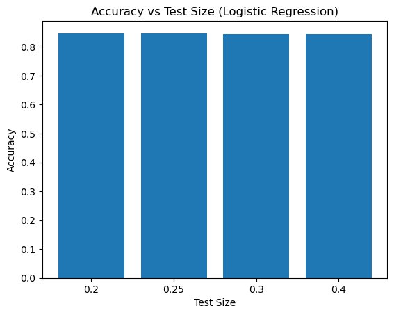

```python
plt.figure()
plt.bar(result_df['Test Size'].astype(str), result_df['Accuracy'])
plt.title('Accuracy vs Test Size (Logistic Regression)')
plt.xlabel('Test Size')
plt.ylabel('Accuracy')
plt.show()
```

```python
from sklearn.neighbors import KNeighborsClassifier

knn_neighbors = [3, 5, 11, 21]  # 필요하면 값 추가/수정
knn_rows = []

for k in knn_neighbors:
    knn_clf = KNeighborsClassifier(n_neighbors=k)
    pipe = Pipeline(steps=[('prep', preprocessor), ('clf', knn_clf)])

    X_train, X_test, y_train, y_test = train_test_split(
        X, y, test_size=0.25, random_state=42, stratify=y
    )
    pipe.fit(X_train, y_train)
    y_pred = pipe.predict(X_test)
    acc = accuracy_score(y_test, y_pred)
    f1w = f1_score(y_test, y_pred, average='weighted')
    knn_rows.append({'Model': f'KNN(k={k})', 'Accuracy': acc, 'F1-weighted': f1w})

knn_df = pd.DataFrame(knn_rows).sort_values('Accuracy', ascending=False).reset_index(drop=True)
print("=== KNN results (varying n_neighbors) ===")
print(knn_df)
```

```
=== KNN results (varying n_neighbors) ===
       Model  Accuracy  F1-weighted
0  KNN(k=21)  0.838450     0.833759
1  KNN(k=11)  0.831595     0.827562
2   KNN(k=5)  0.819970     0.815787
3   KNN(k=3)  0.811028     0.807557
```

```python
from sklearn.tree import DecisionTreeClassifier

leaf_values  = [1, 5, 10]
depth_values = [None, 5, 10, 20]

dt_rows = []
for leaf in leaf_values:
    for depth in depth_values:
        dt = DecisionTreeClassifier(min_samples_leaf=leaf, max_depth=depth, random_state=42)
        pipe = Pipeline(steps=[('prep', preprocessor), ('clf', dt)])

        X_train, X_test, y_train, y_test = train_test_split(
            X, y, test_size=0.25, random_state=42, stratify=y
        )
        pipe.fit(X_train, y_train)
        y_pred = pipe.predict(X_test)
        acc = accuracy_score(y_test, y_pred)
        f1w = f1_score(y_test, y_pred, average='weighted')
        dt_rows.append({
            'Model': f'DecisionTree(leaf={leaf}, depth={depth})',
            'min_samples_leaf': leaf,
            'max_depth': depth,
            'Accuracy': acc,
            'F1-weighted': f1w
        })

dt_df = pd.DataFrame(dt_rows).sort_values('Accuracy', ascending=False).reset_index(drop=True)
print("=== Decision Tree hyperparameter grid ===")
print(dt_df.head(10))  # 상위 10개만 출력
```

```
=== Decision Tree hyperparameter grid ===
                               Model  min_samples_leaf  max_depth  Accuracy  \
0    DecisionTree(leaf=10, depth=10)                10       10.0  0.844262
1     DecisionTree(leaf=5, depth=10)                 5       10.0  0.843666
2     DecisionTree(leaf=1, depth=10)                 1       10.0  0.841282
3    DecisionTree(leaf=10, depth=20)                10       20.0  0.834724
4      DecisionTree(leaf=1, depth=5)                 1        5.0  0.833383
5      DecisionTree(leaf=5, depth=5)                 5        5.0  0.833383
6     DecisionTree(leaf=10, depth=5)                10        5.0  0.833383
7  DecisionTree(leaf=10, depth=None)                10        NaN  0.829657
8     DecisionTree(leaf=5, depth=20)                 5       20.0  0.825186
9   DecisionTree(leaf=5, depth=None)                 5        NaN  0.820119

   F1-weighted
0     0.838160
1     0.837994
2     0.835564
3     0.831059
4     0.823404
5     0.823404
6     0.823454
7     0.825477
8     0.821063
9     0.816382
```

```python
from sklearn.naive_bayes import BernoulliNB, MultinomialNB
from sklearn.preprocessing import MinMaxScaler

nb_preprocessor = ColumnTransformer(
    transformers=[
        ('num', MinMaxScaler(), num_features),
        ('cat', OneHotEncoder(handle_unknown='ignore'), cat_features)
    ]
)

nb_rows = []
for name, nb in [('BernoulliNB', BernoulliNB()), ('MultinomialNB', MultinomialNB())]:
    pipe = Pipeline(steps=[('prep', nb_preprocessor), ('clf', nb)])
    X_train, X_test, y_train, y_test = train_test_split(
        X, y, test_size=0.25, random_state=42, stratify=y
    )
    pipe.fit(X_train, y_train)
    y_pred = pipe.predict(X_test)
    acc = accuracy_score(y_test, y_pred)
    f1w = f1_score(y_test, y_pred, average='weighted')
    nb_rows.append({'Model': name, 'Accuracy': acc, 'F1-weighted': f1w})

nb_df = pd.DataFrame(nb_rows).sort_values('Accuracy', ascending=False).reset_index(drop=True)
print("=== Naive Bayes variants ===")
print(nb_df)
```

```
=== Naive Bayes variants ===
           Model  Accuracy  F1-weighted
0  MultinomialNB  0.809389     0.816239
1    BernoulliNB  0.781222     0.792113
```

```python
summary = []

# 이전 셀에서 만든 result_df(스플릿 비교), knn_df, dt_df, nb_df가 있다고 가정
if 'result_df' in globals():
    tmp = result_df.copy()
    tmp['Model'] = 'LogReg (var test_size)'
    summary.append(tmp.rename(columns={'Test Size': 'Note'}))

tmp = knn_df.copy(); tmp['Note'] = knn_df['Model']; tmp['Model'] = 'KNN'
summary.append(tmp[['Model', 'Note', 'Accuracy', 'F1-weighted']])

tmp = dt_df.copy(); tmp['Note'] = dt_df['Model']; tmp['Model'] = 'DecisionTree'
summary.append(tmp[['Model', 'Note', 'Accuracy', 'F1-weighted']])

tmp = nb_df.copy(); tmp['Note'] = nb_df['Model']; tmp['Model'] = 'NaiveBayes'
summary.append(tmp[['Model', 'Note', 'Accuracy', 'F1-weighted']])

summary_df = pd.concat(summary, ignore_index=True)
print("=== Summary of all experiments ===")
print(summary_df.sort_values(['Model', 'Accuracy'], ascending=[True, False]).head(20))
```

```
=== Summary of all experiments ===
                                 Note  Accuracy  F1-weighted  \
8     DecisionTree(leaf=10, depth=10)  0.844262     0.838160
9      DecisionTree(leaf=5, depth=10)  0.843666     0.837994
10     DecisionTree(leaf=1, depth=10)  0.841282     0.835564
11    DecisionTree(leaf=10, depth=20)  0.834724     0.831059
12      DecisionTree(leaf=1, depth=5)  0.833383     0.823404
13      DecisionTree(leaf=5, depth=5)  0.833383     0.823404
14     DecisionTree(leaf=10, depth=5)  0.833383     0.823454
15  DecisionTree(leaf=10, depth=None)  0.829657     0.825477
16     DecisionTree(leaf=5, depth=20)  0.825186     0.821063
17   DecisionTree(leaf=5, depth=None)  0.820119     0.816382
18     DecisionTree(leaf=1, depth=20)  0.809687     0.808581
19   DecisionTree(leaf=1, depth=None)  0.789419     0.788408
4                           KNN(k=21)  0.838450     0.833759
```

[output cut: 29 more lines]